# Prosper Loan Data Analysis

## Introduction

The main purpose of this project is to use Python visualization libraries to systematically explore a selected dataset, starting from plots of single variables and building up to plots of multiple variables and producing a summary highlights showing trends and relationships discovered in the Loan Data from Prosper. Questions to be explored:

- What factors affect a loan’s outcome status?. The variables to be considerred are as follows.
  - Employment status
  - IncomeRange
  - Prosper Score
  - Home owner status
  - Borrower State
- What affects the borrower’s APR or interest rate?
  - Loan original amount
  - Listing Category

## Dataset Overview

The Loan Data from Prosper contains 113,937 loans with 81 variables on each loan, including loan amount, borrower rate (or interest rate), current loan status, borrower income, borrower credit history, and the latest payment information.

## Preliminary Wrangling

```python
# import all packages and set plots to be embedded inline
import numpy as np
import pandas as pd
import matplotlib.pyplot as plt
import seaborn as sb

%matplotlib inline
```

```python
#load dataset into panda Dataframe
df = pd.read_csv('prosperLoanData.csv')
df.head()
```

|  | ListingKey | ListingNumber | ListingCreationDate | CreditGrade | Term | LoanStatus | ClosedDate | BorrowerAPR | BorrowerRate | LenderYield | ... | LP_ServiceFees | LP_CollectionFees | LP_GrossPrincipalLoss | LP_NetPrincipalLoss | LP_NonPrincipalRecoverypayments | PercentFunded | Recommendations | InvestmentFromFriendsCount | InvestmentFromFriendsAmount | Investors |
| --- | --- | --- | --- | --- | --- | --- | --- | --- | --- | --- | --- | --- | --- | --- | --- | --- | --- | --- | --- | --- | --- |
| 0 | 1021339766868145413AB3B | 193129 | 2007-08-26 19:09:29.263000000 | C | 36 | Completed | 2009-08-14 00:00:00 | 0.16516 | 0.1580 | 0.1380 | ... | -133.18 | 0.0 | 0.0 | 0.0 | 0.0 | 1.0 | 0 | 0 | 0.0 | 258 |
| 1 | 10273602499503308B223C1 | 1209647 | 2014-02-27 08:28:07.900000000 | NaN | 36 | Current | NaN | 0.12016 | 0.0920 | 0.0820 | ... | 0.00 | 0.0 | 0.0 | 0.0 | 0.0 | 1.0 | 0 | 0 | 0.0 | 1 |
| 2 | 0EE9337825851032864889A | 81716 | 2007-01-05 15:00:47.090000000 | HR | 36 | Completed | 2009-12-17 00:00:00 | 0.28269 | 0.2750 | 0.2400 | ... | -24.20 | 0.0 | 0.0 | 0.0 | 0.0 | 1.0 | 0 | 0 | 0.0 | 41 |
| 3 | 0EF5356002482715299901A | 658116 | 2012-10-22 11:02:35.010000000 | NaN | 36 | Current | NaN | 0.12528 | 0.0974 | 0.0874 | ... | -108.01 | 0.0 | 0.0 | 0.0 | 0.0 | 1.0 | 0 | 0 | 0.0 | 158 |
| 4 | 0F023589499656230C5E3E2 | 909464 | 2013-09-14 18:38:39.097000000 | NaN | 36 | Current | NaN | 0.24614 | 0.2085 | 0.1985 | ... | -60.27 | 0.0 | 0.0 | 0.0 | 0.0 | 1.0 | 0 | 0 | 0.0 | 20 |

5 rows × 81 columns

```python
#checking data structure
df.info()
```

```
<class 'pandas.core.frame.DataFrame'>
RangeIndex: 113937 entries, 0 to 113936
Data columns (total 81 columns):
 #   Column                               Non-Null Count   Dtype
---  ------                               --------------   -----
 0   ListingKey                           113937 non-null  object
 1   ListingNumber                        113937 non-null  int64
 2   ListingCreationDate                  113937 non-null  object
 3   CreditGrade                          28953 non-null   object
 4   Term                                 113937 non-null  int64
 5   LoanStatus                           113937 non-null  object
 6   ClosedDate                           55089 non-null   object
 7   BorrowerAPR                          113912 non-null  float64
 8   BorrowerRate                         113937 non-null  float64
 9   LenderYield                          113937 non-null  float64
```

[output cut: 73 more lines]

```python
#checking data description
df.describe()
```

|  | ListingNumber | Term | BorrowerAPR | BorrowerRate | LenderYield | EstimatedEffectiveYield | EstimatedLoss | EstimatedReturn | ProsperRating (numeric) | ProsperScore | ... | LP_ServiceFees | LP_CollectionFees | LP_GrossPrincipalLoss | LP_NetPrincipalLoss | LP_NonPrincipalRecoverypayments | PercentFunded | Recommendations | InvestmentFromFriendsCount | InvestmentFromFriendsAmount | Investors |
| --- | --- | --- | --- | --- | --- | --- | --- | --- | --- | --- | --- | --- | --- | --- | --- | --- | --- | --- | --- | --- | --- |
| count | 1.139370e+05 | 113937.000000 | 113912.000000 | 113937.000000 | 113937.000000 | 84853.000000 | 84853.000000 | 84853.000000 | 84853.000000 | 84853.000000 | ... | 113937.000000 | 113937.000000 | 113937.000000 | 113937.000000 | 113937.000000 | 113937.000000 | 113937.000000 | 113937.000000 | 113937.000000 | 113937.000000 |
| mean | 6.278857e+05 | 40.830248 | 0.218828 | 0.192764 | 0.182701 | 0.168661 | 0.080306 | 0.096068 | 4.072243 | 5.950067 | ... | -54.725641 | -14.242698 | 700.446342 | 681.420499 | 25.142686 | 0.998584 | 0.048027 | 0.023460 | 16.550751 | 80.475228 |
| std | 3.280762e+05 | 10.436212 | 0.080364 | 0.074818 | 0.074516 | 0.068467 | 0.046764 | 0.030403 | 1.673227 | 2.376501 | ... | 60.675425 | 109.232758 | 2388.513831 | 2357.167068 | 275.657937 | 0.017919 | 0.332353 | 0.232412 | 294.545422 | 103.239020 |
| min | 4.000000e+00 | 12.000000 | 0.006530 | 0.000000 | -0.010000 | -0.182700 | 0.004900 | -0.182700 | 1.000000 | 1.000000 | ... | -664.870000 | -9274.750000 | -94.200000 | -954.550000 | 0.000000 | 0.700000 | 0.000000 | 0.000000 | 0.000000 | 1.000000 |
| 25% | 4.009190e+05 | 36.000000 | 0.156290 | 0.134000 | 0.124200 | 0.115670 | 0.042400 | 0.074080 | 3.000000 | 4.000000 | ... | -73.180000 | 0.000000 | 0.000000 | 0.000000 | 0.000000 | 1.000000 | 0.000000 | 0.000000 | 0.000000 | 2.000000 |
| 50% | 6.005540e+05 | 36.000000 | 0.209760 | 0.184000 | 0.173000 | 0.161500 | 0.072400 | 0.091700 | 4.000000 | 6.000000 | ... | -34.440000 | 0.000000 | 0.000000 | 0.000000 | 0.000000 | 1.000000 | 0.000000 | 0.000000 | 0.000000 | 44.000000 |
| 75% | 8.926340e+05 | 36.000000 | 0.283810 | 0.250000 | 0.240000 | 0.224300 | 0.112000 | 0.116600 | 5.000000 | 8.000000 | ... | -13.920000 | 0.000000 | 0.000000 | 0.000000 | 0.000000 | 1.000000 | 0.000000 | 0.000000 | 0.000000 | 115.000000 |
| max | 1.255725e+06 | 60.000000 | 0.512290 | 0.497500 | 0.492500 | 0.319900 | 0.366000 | 0.283700 | 7.000000 | 11.000000 | ... | 32.060000 | 0.000000 | 25000.000000 | 25000.000000 | 21117.900000 | 1.012500 | 39.000000 | 33.000000 | 25000.000000 | 1189.000000 |

8 rows × 61 columns

```python
#selected variables for analysis based on the questions to inquiry the dataset
#based on the variable definition and columns wiht less no nulls values
selected_variables=['LoanStatus', 'IsBorrowerHomeowner','IncomeRange', 'EmploymentStatus','ListingCategory (numeric)',
                    'LoanOriginalAmount','BorrowerState','BorrowerAPR','ProsperScore','DebtToIncomeRatio']

s_df=df[selected_variables]

s_df.info()
```

```
<class 'pandas.core.frame.DataFrame'>
RangeIndex: 113937 entries, 0 to 113936
Data columns (total 10 columns):
 #   Column                     Non-Null Count   Dtype
---  ------                     --------------   -----
 0   LoanStatus                 113937 non-null  object
 1   IsBorrowerHomeowner        113937 non-null  bool
 2   IncomeRange                113937 non-null  object
 3   EmploymentStatus           111682 non-null  object
 4   ListingCategory (numeric)  113937 non-null  int64
 5   LoanOriginalAmount         113937 non-null  int64
 6   BorrowerState              108422 non-null  object
 7   BorrowerAPR                113912 non-null  float64
 8   ProsperScore               84853 non-null   float64
 9   DebtToIncomeRatio          105383 non-null  float64
dtypes: bool(1), float64(3), int64(2), object(4)
memory usage: 7.9+ MB
```

```python
#checking unique values in column using a for looop
for col in s_df:
    print(col)
    print(s_df[col].unique())
```

```
LoanStatus
['Completed' 'Current' 'Past Due (1-15 days)' 'Defaulted' 'Chargedoff'
 'Past Due (16-30 days)' 'Cancelled' 'Past Due (61-90 days)'
 'Past Due (31-60 days)' 'Past Due (91-120 days)' 'FinalPaymentInProgress'
 'Past Due (>120 days)']
IsBorrowerHomeowner
[ True False]
IncomeRange
['$25,000-49,999' '$50,000-74,999' 'Not displayed' '$100,000+'
 '$75,000-99,999' '$1-24,999' 'Not employed' '$0']
EmploymentStatus
['Self-employed' 'Employed' 'Not available' 'Full-time' 'Other' nan
 'Not employed' 'Part-time' 'Retired']
ListingCategory (numeric)
[ 0  2 16  1  7 13  6 15 20 19  3 18  8  4 11 14  5  9 17 10 12]
LoanOriginalAmount
[ 9425 10000  3001 ... 17669 19432  4292]
BorrowerState
['CO' 'GA' 'MN' 'NM' 'KS' 'CA' 'IL' 'MD' nan 'AL' 'AZ' 'VA' 'FL' 'PA' 'OR'
 'MI' 'NY' 'LA' 'WI' 'OH' 'NC' 'WA' 'NV' 'NJ' 'TX' 'AR' 'SC' 'DE' 'MO'
 'NE' 'UT' 'DC' 'MA' 'CT' 'IN' 'KY' 'OK' 'MS' 'WV' 'RI' 'TN' 'ID' 'MT'
 'HI' 'NH' 'VT' 'WY' 'ME' 'AK' 'IA' 'SD' 'ND']
BorrowerAPR
[0.16516 0.12016 0.28269 ... 0.22674 0.3477  0.19543]
ProsperScore
[nan  7.  9.  4. 10.  2. 11.  8.  5.  3.  6.  1.]
DebtToIncomeRatio
[0.17    0.18    0.06    ... 0.3108  0.07419 0.23284]
```

```python
top3_categories = ['Completed', 'Current', 'Chargedoff']
s_df= s_df[s_df['LoanStatus'].isin(top3_categories)]
s_df
```

|  | LoanStatus | IsBorrowerHomeowner | IncomeRange | EmploymentStatus | ListingCategory (numeric) | LoanOriginalAmount | BorrowerState | BorrowerAPR | ProsperScore | DebtToIncomeRatio |
| --- | --- | --- | --- | --- | --- | --- | --- | --- | --- | --- |
| 0 | Completed | True | $25,000-49,999 | Self-employed | 0 | 9425 | CO | 0.16516 | NaN | 0.17 |
| 1 | Current | False | $50,000-74,999 | Employed | 2 | 10000 | CO | 0.12016 | 7.0 | 0.18 |
| 2 | Completed | False | Not displayed | Not available | 0 | 3001 | GA | 0.28269 | NaN | 0.06 |
| 3 | Current | True | $25,000-49,999 | Employed | 16 | 10000 | GA | 0.12528 | 9.0 | 0.15 |
| 4 | Current | True | $100,000+ | Employed | 2 | 15000 | MN | 0.24614 | 4.0 | 0.26 |
| ... | ... | ... | ... | ... | ... | ... | ... | ... | ... | ... |
| 113931 | Current | False | $75,000-99,999 | Employed | 3 | 25000 | IL | 0.15016 | 6.0 | 0.28 |
| 113932 | Current | True | $50,000-74,999 | Employed | 1 | 10000 | IL | 0.22354 | 5.0 | 0.13 |
| 113934 | Current | True | $25,000-49,999 | Employed | 1 | 10000 | TX | 0.23984 | 3.0 | 0.51 |
| 113935 | Completed | True | $25,000-49,999 | Full-time | 2 | 15000 | GA | 0.28408 | 5.0 | 0.48 |
| 113936 | Current | False | $50,000-74,999 | Employed | 1 | 2000 | NY | 0.13189 | 7.0 | 0.23 |

106642 rows × 10 columns

```python
# Loans have multiple categories show top 3 only
s_df['LoanStatus'].value_counts()
```

```
Current       56576
Completed     38074
Chargedoff    11992
Name: LoanStatus, dtype: int64
```

```python
#change name of ListingCategory (numeric)
s_df= s_df.rename(columns={'ListingCategory (numeric)':'Typeofdebt'})
s_df.info()
```

```
<class 'pandas.core.frame.DataFrame'>
Int64Index: 106642 entries, 0 to 113936
Data columns (total 10 columns):
 #   Column               Non-Null Count   Dtype
---  ------               --------------   -----
 0   LoanStatus           106642 non-null  object
 1   IsBorrowerHomeowner  106642 non-null  bool
 2   IncomeRange          106642 non-null  object
 3   EmploymentStatus     104912 non-null  object
 4   Typeofdebt           106642 non-null  int64
 5   LoanOriginalAmount   106642 non-null  int64
 6   BorrowerState        101719 non-null  object
 7   BorrowerAPR          106617 non-null  float64
 8   ProsperScore         81576 non-null   float64
 9   DebtToIncomeRatio    98569 non-null   float64
dtypes: bool(1), float64(3), int64(2), object(4)
memory usage: 8.2+ MB
```

```python
#drop missing values
s_df.dropna(inplace=True)
```

```python
#checking changes
s_df.info()
```

```
<class 'pandas.core.frame.DataFrame'>
Int64Index: 74626 entries, 1 to 113936
Data columns (total 10 columns):
 #   Column               Non-Null Count  Dtype
---  ------               --------------  -----
 0   LoanStatus           74626 non-null  object
 1   IsBorrowerHomeowner  74626 non-null  bool
 2   IncomeRange          74626 non-null  object
 3   EmploymentStatus     74626 non-null  object
 4   Typeofdebt           74626 non-null  int64
 5   LoanOriginalAmount   74626 non-null  int64
 6   BorrowerState        74626 non-null  object
 7   BorrowerAPR          74626 non-null  float64
 8   ProsperScore         74626 non-null  float64
 9   DebtToIncomeRatio    74626 non-null  float64
dtypes: bool(1), float64(3), int64(2), object(4)
memory usage: 5.8+ MB
```

```python
# Assigning a name to each value
s_df['Typeofdebt'] = s_df['Typeofdebt'].map({0:'Not Available', 1:'Debt Consolidation', 2:'Home Improvement', 3:'Business', 4:'Personal Loan', 5:'Student Use', 6:'Auto', 7:'Other', 8:'Baby&Adoption', 9:'Boat', 10: 'Cosmetic Procedure', 11:'Engagement Ring', 12:'Green Loans', 13:'Household Expenses', 14:'Large Purchases', 15:'Medical/Dental', 16:'Motorcycle', 17:'RV', 18:'Taxes', 19:'Vacation', 20:'Wedding Loans'})
s_df ['Typeofdebt'].value_counts()
```

```
Debt Consolidation    48079
Other                  8007
Home Improvement       6077
Business               3456
Auto                   1953
Household Expenses     1699
Medical/Dental         1323
Large Purchases         761
Taxes                   755
Wedding Loans           706
Vacation                690
Motorcycle              279
Student Use             195
Engagement Ring         193
Baby&Adoption           186
Boat                     81
Cosmetic Procedure       78
RV                       48
Green Loans              42
Not Available            18
Name: Typeofdebt, dtype: int64
```

```python
#check changes
s_df.head()
```

|  | LoanStatus | IsBorrowerHomeowner | IncomeRange | EmploymentStatus | Typeofdebt | LoanOriginalAmount | BorrowerState | BorrowerAPR | ProsperScore | DebtToIncomeRatio |
| --- | --- | --- | --- | --- | --- | --- | --- | --- | --- | --- |
| 1 | Current | False | $50,000-74,999 | Employed | Home Improvement | 10000 | CO | 0.12016 | 7.0 | 0.18 |
| 3 | Current | True | $25,000-49,999 | Employed | Motorcycle | 10000 | GA | 0.12528 | 9.0 | 0.15 |
| 4 | Current | True | $100,000+ | Employed | Home Improvement | 15000 | MN | 0.24614 | 4.0 | 0.26 |
| 5 | Current | True | $100,000+ | Employed | Debt Consolidation | 15000 | NM | 0.15425 | 10.0 | 0.36 |
| 6 | Current | False | $25,000-49,999 | Employed | Debt Consolidation | 3000 | KS | 0.31032 | 2.0 | 0.27 |

```python
# Check Income rnage
s_df.IncomeRange
```

```
1         $50,000-74,999
3         $25,000-49,999
4              $100,000+
5              $100,000+
6         $25,000-49,999
               ...
113931    $75,000-99,999
113932    $50,000-74,999
113934    $25,000-49,999
113935    $25,000-49,999
113936    $50,000-74,999
Name: IncomeRange, Length: 74626, dtype: object
```

```python
#Income chnage ordering
from pandas.api.types import CategoricalDtype
IncomeRange_ = ['Not displayed', 'Not employed','$0', '$1-24,999', '$25,000-49,999', '$50,000-74,999', '$75,000-99,999','$100,000+']
o_ = CategoricalDtype(categories=IncomeRange_, ordered=True)
s_df.IncomeRange = s_df.IncomeRange.astype(o_)
```

```python
#check changes
s_df.head()
```

|  | LoanStatus | IsBorrowerHomeowner | IncomeRange | EmploymentStatus | Typeofdebt | LoanOriginalAmount | BorrowerState | BorrowerAPR | ProsperScore | DebtToIncomeRatio |
| --- | --- | --- | --- | --- | --- | --- | --- | --- | --- | --- |
| 1 | Current | False | $50,000-74,999 | Employed | Home Improvement | 10000 | CO | 0.12016 | 7.0 | 0.18 |
| 3 | Current | True | $25,000-49,999 | Employed | Motorcycle | 10000 | GA | 0.12528 | 9.0 | 0.15 |
| 4 | Current | True | $100,000+ | Employed | Home Improvement | 15000 | MN | 0.24614 | 4.0 | 0.26 |
| 5 | Current | True | $100,000+ | Employed | Debt Consolidation | 15000 | NM | 0.15425 | 10.0 | 0.36 |
| 6 | Current | False | $25,000-49,999 | Employed | Debt Consolidation | 3000 | KS | 0.31032 | 2.0 | 0.27 |

```python
#check changes 2
s_df.info()
```

```
<class 'pandas.core.frame.DataFrame'>
Int64Index: 74626 entries, 1 to 113936
Data columns (total 10 columns):
 #   Column               Non-Null Count  Dtype
---  ------               --------------  -----
 0   LoanStatus           74626 non-null  object
 1   IsBorrowerHomeowner  74626 non-null  bool
 2   IncomeRange          74626 non-null  category
 3   EmploymentStatus     74626 non-null  object
 4   Typeofdebt           74626 non-null  object
 5   LoanOriginalAmount   74626 non-null  int64
 6   BorrowerState        74626 non-null  object
 7   BorrowerAPR          74626 non-null  float64
 8   ProsperScore         74626 non-null  float64
 9   DebtToIncomeRatio    74626 non-null  float64
dtypes: bool(1), category(1), float64(3), int64(1), object(4)
memory usage: 5.3+ MB
```

## Univariate Exploration

In this section, investigate distributions of individual variables. If you see unusual points or outliers, take a deeper look to clean things up and prepare yourself to look at relationships between variables.

# What is the Borrower APR distribution?

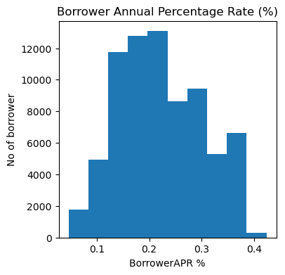

```python
#Understading Borrowers APR (The Borrower's Annual Percentage Rate (APR) for the loan)
def x_y_t(xL, yL, tittel, data):
    plt.figure(figsize=[4,4])
    plt.title(tittel)
    plt.xlabel(xL)
    plt.ylabel(yL)
    plt.hist(data)
    plt.show()

data = s_df['BorrowerAPR']
xL = 'BorrowerAPR %'
yL = 'No of borrower'
tittel = 'Borrower Annual Percentage Rate (%)'

x_y_t(xL, yL, tittel, data)
```

## How is the loan status categorised?

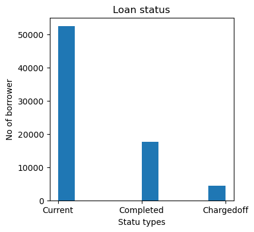

```python
def x_y_t(xL, yL, tittel, data):
    plt.figure(figsize=[4,4])
    plt.title(tittel)
    plt.xlabel(xL)
    plt.ylabel(yL)
    plt.hist(data)
    plt.show()

data = s_df['LoanStatus']
xL = 'Statu types'
yL = 'No of borrower'
tittel = 'Loan status'

x_y_t(xL, yL, tittel, data)
```

Most of the loans are current , followed by completed and Charged off

# What are the Employment status categories?

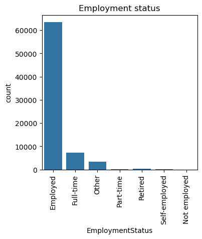

```python
# Employment status
plt.figure(figsize=[4,4])
sb.countplot(data = s_df, x = 'EmploymentStatus', color=sb.color_palette()[0]);
plt.xticks(rotation = 90)
plt.title('Employment status');
```

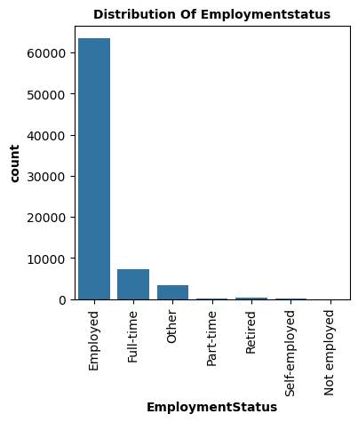

```python
def cust_plot(df, xVar):
    plt.figure(figsize=[4, 4])
    plt.title(f'''Distribution of {xVar.title()}'''.title(), fontsize=10, weight='bold')
    plt.xlabel(xVar.title(), fontsize=10, weight='bold')
    plt.ylabel('Count'.title(), fontsize=10, weight='bold')
    sb.countplot(data=df, x=xVar, color=sb.color_palette()[0])
    plt.xticks(rotation = 90)
    plt.show()

# Example usage
df = s_df  # Replace with your DataFrame
xVar = 'EmploymentStatus'  # Replace with the column name you want to plot

cust_plot(df, xVar)
```

**Observation**: Employed clients have the most common type of employment

# What is the most common type of debt?

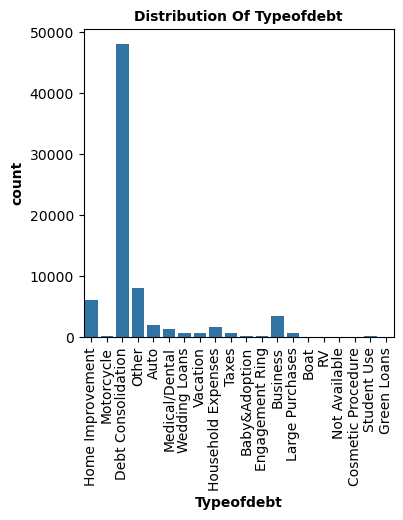

```python
def cust_plot(df, xVar):
    plt.figure(figsize=[4, 4])
    plt.title(f'''Distribution of {xVar.title()}'''.title(), fontsize=10, weight='bold')
    plt.xlabel(xVar.title(), fontsize=10, weight='bold')
    plt.ylabel('Count'.title(), fontsize=10, weight='bold')
    sb.countplot(data=df, x=xVar, color=sb.color_palette()[0])
    plt.xticks(rotation = 90)
    plt.show()

# Example usage
df = s_df  # Replace with your DataFrame
xVar = 'Typeofdebt'  # Replace with the column name you want to plot

cust_plot(df, xVar)
```

**Observation**: Debt consolidation is the most common debt amount

# What is the distribuition of home owners status?

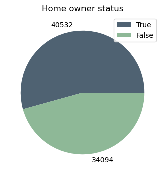

```python
# Home ower status
plt.figure(figsize=[4,4])
colors = ['#4F6272', '#8EB897']
values = s_df['IsBorrowerHomeowner'].value_counts()
plt.pie(values, labels= values, colors=colors)
plt.legend(values.index)
plt.title('Home owner status');
```

**Observation**: Most of the borrowers are home owners

# What is th emost common Prosper Score?

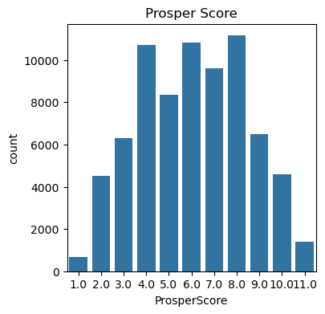

```python
#prosper score
plt.figure(figsize=[4,4])
sb.countplot(data = s_df, x = 'ProsperScore', color=sb.color_palette()[0])
plt.title('Prosper Score');
```

**Observation**: Prosper Score appears to be between 4 and 8

# What is the range of loan amounts?

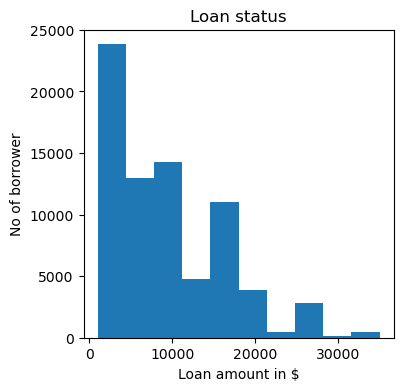

```python
def x_y_t(xL, yL, tittel, data):
    plt.figure(figsize=[4,4])
    binsize = 500
    bins = np.arange(0, data.max()+binsize, binsize)
    plt.title(tittel)
    plt.xlabel(xL)
    plt.ylabel(yL)
    plt.hist(data)
    plt.show()

data = s_df['LoanOriginalAmount']
xL = 'Loan amount in $'
yL = 'No of borrower'
tittel = 'Loan status'

x_y_t(xL, yL, tittel, data)
```

**Observation**: There are various picks (5,000 , 10,000 , 15,000, 20,000 , 25,000). It is appears to be a multimodal distribution

# How are the income ranges distributed?

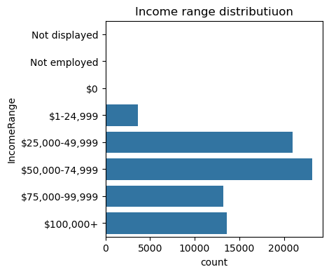

```python
#Income distribution and debtoincome
plt.figure(figsize=[4,4])
sb.countplot(data= s_df, y = 'IncomeRange', color=sb.color_palette()[0])
plt.title('Income range distributiuon');
```

**Observation**: The highest income break is $50,000-$74,999, followed by $25,000-$49,000

# Which States are granting more loans?

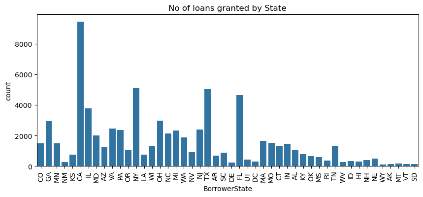

```python
#Borrower state
plt.figure(figsize=[10,4])
sb.countplot(x='BorrowerState', data=s_df, color=sb.color_palette()[0])
plt.xticks(rotation = 90)
plt.title('No of loans granted by State');
plt.show()
```

## Bivariate Exploration

> In this section, investigate relationships between pairs of variables in your data. Make sure the variables that you cover here have been introduced in some fashion in the previous section (univariate exploration).

```python
# Set values that are integers and objects
Values_inter= ['ProsperScore','BorrowerAPR','LoanOriginalAmount']
values_obje=['IsBorrowerHomeowner','IncomeRange','BorrowerState']
```

## Are there relationship across the variables ProsperScore, BorrowerAPR, Loan amount?

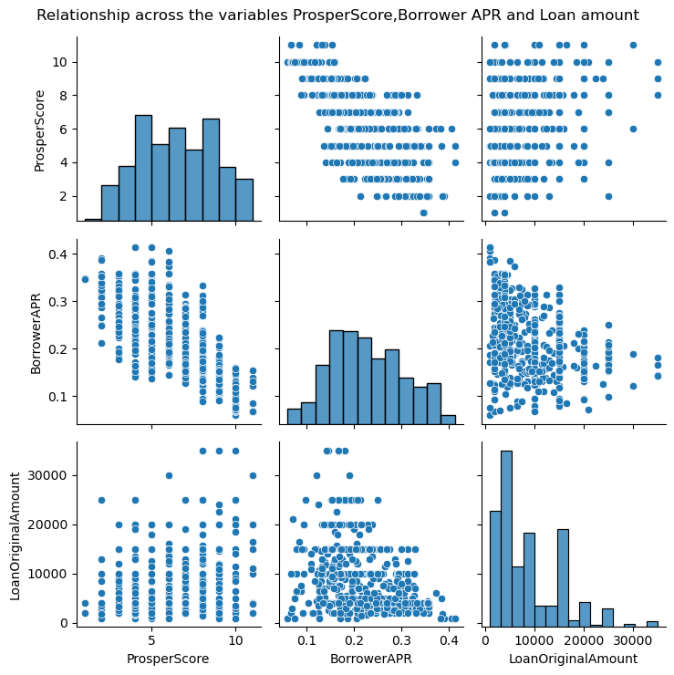

```python
# Correlation between relevant variables- randomsample of 1000 value integer
s_df_sample = s_df.sample(n=500, replace = False)
chart1 = sb.PairGrid(data = s_df_sample, vars = Values_inter)
chart1.map_diag(sb.histplot);
chart1.map_offdiag(sb.scatterplot)
plt.suptitle('Relationship across the variables ProsperScore,Borrower APR and Loan amount')
plt.tight_layout();
```

**Observation**: There is a negative relationship between Borrower APR and ProsperScore. There is a positive relatioship between Loan Amount increase when ProsperScore increases. No relationship between Borrower APR and Loan Amount.

# Is there a correlation between Prosper SCores and Borrower APR?

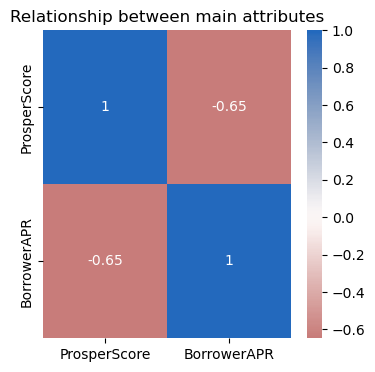

```python
#Relationship between main attributes
multicorrelation_df = s_df_sample[['ProsperScore','BorrowerAPR']]

# correlation plot
plt.figure(figsize=[4,4])
sb.heatmap(multicorrelation_df.corr(), annot = True,
           cmap = 'vlag_r', center = 0)
plt.title('Relationship between main attributes')
```

**Observation**: There is a negative relationship between ProsperScore and BorrowerAPR. The higher the ProsperScore the lower the interets rate charged.

# Are higher income earners getting lower Borrower APR?

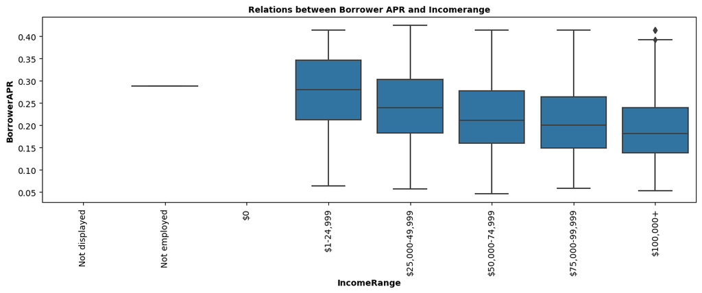

```python
def cust_plot(df, xVar):
    plt.figure(figsize=[14, 4])
    plt.title(f'Relations between Borrower APR and {xVar.title()}', fontsize=10, weight='bold')
    plt.xlabel(xVar.title(), fontsize=10, weight='bold')
    plt.ylabel('BorrowerAPR', fontsize=10, weight='bold')
    sb.boxplot(data=df, x=xVar, y='BorrowerAPR', color=sb.color_palette()[0])
    plt.xticks(rotation=90)
    plt.show()

# Example usage
df = s_df  # Replace with your DataFrame
xVar = 'IncomeRange'  # Replace with the column name you want to plot

cust_plot(df, xVar)
```

**Observation**: It seems that Borrowers APR decrease the higher the income range

# How Prosper Score vary by loan status?

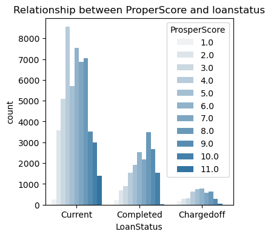

```python
#Second, plot the histogram wiht top 3 loan categories
plt.figure(figsize=[4,4])
sb.countplot(data =s_df, x = 'LoanStatus', hue = 'ProsperScore', color=sb.color_palette()[0])
plt.title('Relationship between ProperScore and loanstatus')
```

# How do Borrowers APR fluctuate across clients with different loand Status and Prosper Score?

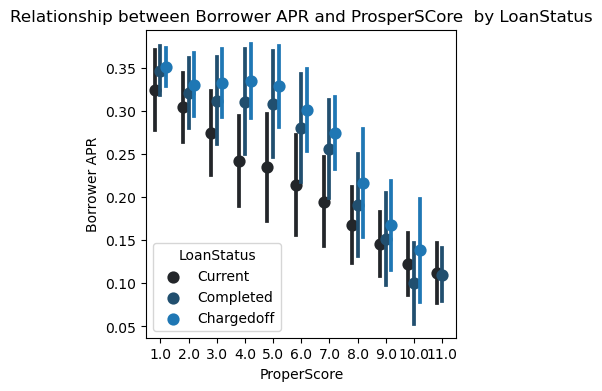

```python
# Relationship between Borrower APR,ProsperScore an dloan status
plt.figure(figsize=[4,4])
ss = sb.pointplot(data = s_df, x = 'ProsperScore', y = 'BorrowerAPR', hue = 'LoanStatus',
           color=sb.color_palette()[0], linestyles = '', dodge = 0.4, errorbar='sd')
plt.title('Relationship between Borrower APR and ProsperSCore  by LoanStatus')
plt.ylabel('Borrower APR')
plt.xlabel('ProperScore')
```

**Observation**: It appears that the higher the ProperScore, the lower the borrower APR wiht current status and charge off as main loan status

## Multivariate Exploration

> Create plots of three or more variables to investigate your data even further. Make sure that your investigations are justified, and follow from your work in the previous sections.

# Do the Borrewer APRs change for home owner clients that are full time employed?

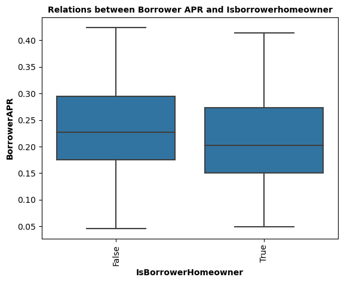

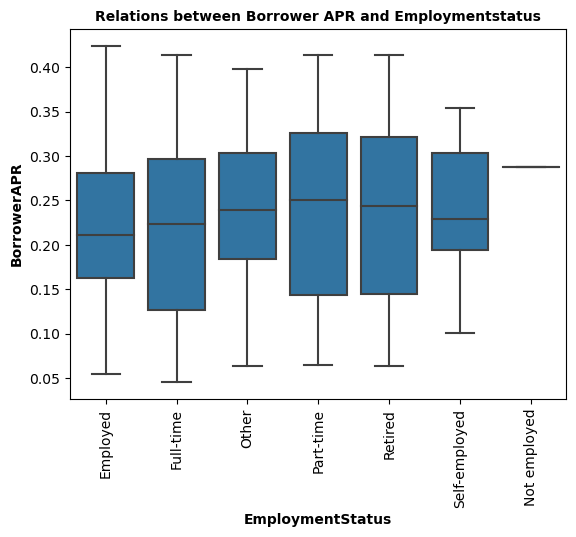

```python
def cust_plot(df, xVar):
    plt.title(f'Relations between Borrower APR and {xVar.title()}', fontsize=10, weight='bold')
    plt.xlabel(xVar.title(), fontsize=10, weight='bold')
    plt.ylabel('BorrowerAPR', fontsize=10, weight='bold')
    sb.boxplot(data=df, x=xVar, y='BorrowerAPR', color=sb.color_palette()[0])
    plt.xticks(rotation=90)
    plt.show()

# Example usage
df = s_df  # Replace with your DataFrame
xVar = 'IsBorrowerHomeowner'  # Replace with the column name you want to plot

cust_plot(df, xVar)


def cust_plot2(df, xVar):
    plt.title(f'Relations between Borrower APR and {xVar.title()}', fontsize=10, weight='bold')
    plt.xlabel(xVar.title(), fontsize=10, weight='bold')
    plt.ylabel('BorrowerAPR', fontsize=10, weight='bold')
    sb.boxplot(data=df, x=xVar, y='BorrowerAPR', color=sb.color_palette()[0])
    plt.xticks(rotation=90)
    plt.show()

# Example usage
df = s_df  # Replace with your DataFrame
xVar = 'EmploymentStatus'  # Replace with the column name you want to plot

cust_plot2(df, xVar)
plt.tight_layout();
plt.figure(figsize=[4,4]);
```

**Observation**: It seems the borrower APR increases when borrowers are retired and self-employed. IT also increase when borrowers do not own their home

# What is the relationhsip (if at all) across employment, loan status and loan amount?

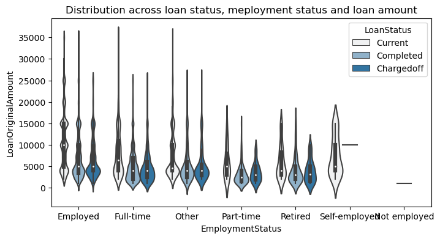

```python
# Relationships across Amount, employment status and Loan Status
plt.figure(figsize=(8,4))
sb.violinplot(data=s_df, x='EmploymentStatus', y='LoanOriginalAmount', hue='LoanStatus',color=sb.color_palette()[0])
plt.title('Distribution across loan status, meployment status and loan amount');
```

**Observation**: Employed and full time clients get higher amount of loans

The loan amount seems to increase with better rating, whereas the borrower APR decreases with better rating

# How employment and loans status impact the Borrower Rate?

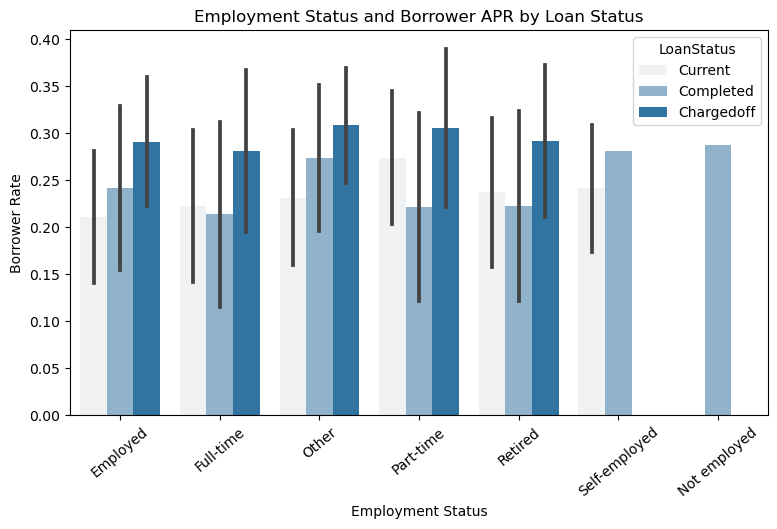

```python
#  Relationship across Employment Status and Borrower APR by Loan Status
plt.figure(figsize=(9,5))
sb.barplot(data=s_df, x='EmploymentStatus', y='BorrowerAPR',
           hue='LoanStatus', errorbar='sd', color=sb.color_palette()[0])

plt.xlabel('Employment Status')
plt.ylabel('Borrower Rate')
plt.title('Employment Status and Borrower APR by Loan Status')
plt.xticks(rotation=40)

plt.show()
```

## Summary of main visualisations

# Are there relationship across the variables ProsperScore, BorrowerAPR, Loan amount?

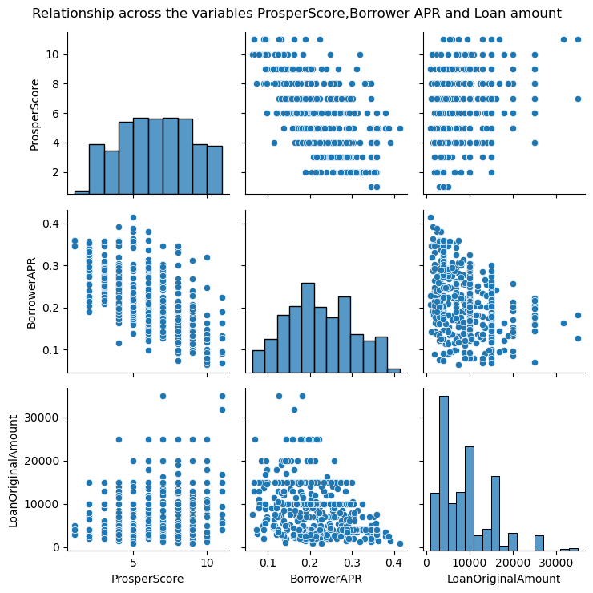

```python
# Correlation between relevant variables- randomsample of 1000 value integer
chart1.fig.set_size_inches(14, 8)
s_df_sample = s_df.sample(n=500, replace = False)
chart1 = sb.PairGrid(data = s_df_sample, vars = Values_inter)
chart1.map_diag(sb.histplot);
chart1.map_offdiag(sb.scatterplot)
plt.suptitle('Relationship across the variables ProsperScore,Borrower APR and Loan amount')
plt.tight_layout();
```

# Do the Borrewer APRs change for home owner clients that are full time employed?

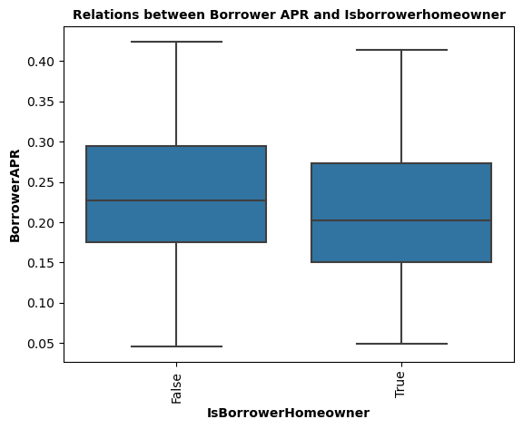

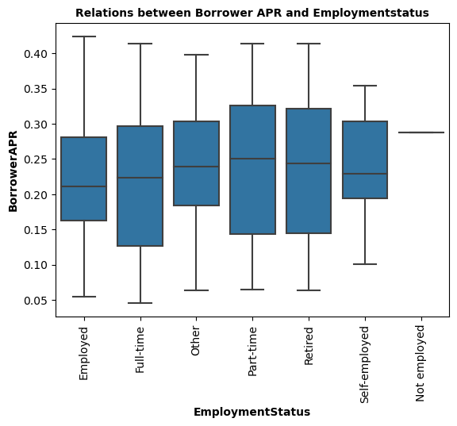

```python
#  Relationship across BorrowerAPR and homeowership status
def cust_plot(df, xVar):
    plt.title(f'Relations between Borrower APR and {xVar.title()}', fontsize=10, weight='bold')
    plt.xlabel(xVar.title(), fontsize=10, weight='bold')
    plt.ylabel('BorrowerAPR', fontsize=10, weight='bold')
    sb.boxplot(data=df, x=xVar, y='BorrowerAPR', color=sb.color_palette()[0])
    plt.xticks(rotation=90)
    plt.show()

# Example usage
df = s_df  # Replace with your DataFrame
xVar = 'IsBorrowerHomeowner'  # Replace with the column name you want to plot

cust_plot(df, xVar)


def cust_plot2(df, xVar):
    plt.title(f'Relations between Borrower APR and {xVar.title()}', fontsize=10, weight='bold')
    plt.xlabel(xVar.title(), fontsize=10, weight='bold')
    plt.ylabel('BorrowerAPR', fontsize=10, weight='bold')
    sb.boxplot(data=df, x=xVar, y='BorrowerAPR', color=sb.color_palette()[0])
    plt.xticks(rotation=90)
    plt.show()

# Example usage
df = s_df  # Replace with your DataFrame
xVar = 'EmploymentStatus'  # Replace with the column name you want to plot

cust_plot2(df, xVar)
plt.tight_layout()
plt.figure(figsize=[14, 4]);
```

# How employment and loans status impact the Borrower Rate?

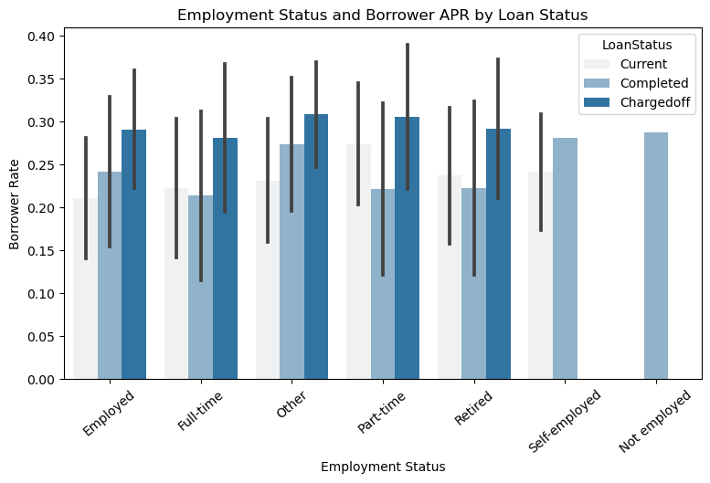

```python
#  Relationship across Rating, Loan Amount and Loan Status

plt.figure(figsize=(9,5))
sb.barplot(data=s_df, x='EmploymentStatus', y='BorrowerAPR',
           hue='LoanStatus', errorbar='sd', color=sb.color_palette()[0])

plt.xlabel('Employment Status')
plt.ylabel('Borrower Rate')
plt.title('Employment Status and Borrower APR by Loan Status')
plt.xticks(rotation=40)

plt.show()
```

## Conclusions

It is also noticed that loan amonts are higher when the Proper Score is hig.

A statistical analysis and modelling is necessary after the Exploratory Data Analysis is underatken to make definitive assertions on the relationhsis and impacts of variables.

# Sources

- https://www.geeksforgeeks.org/python-pandas-categoricaldtype/
- https://stackoverflow.com/questions/62247882/how-to-find-the-different-variables-of-a-column
- https://stackoverflow.com/questions/11285613/selecting-multiple-columns-in-a-pandas-dataframe
- https://docs.google.com/spreadsheets/d/1gDyi_L4UvIrLTEC6Wri5nbaMmkGmLQBk-Yx3z0XDEtI/edit#gid=0
- https://learn.udacity.com/nanodegrees/nd002/parts/cd0016/lessons/ls2240/concepts/0b1f1304-f77f-42d6-a50e-d4fe7f977774
- https://stackoverflow.com/questions/72970343/plotting-top-10-values-in-big-data
- https://www.codeproject.com/Questions/5337174/Plotting-top-10-values-in-big-data-Python
- https://seaborn.pydata.org/generated/seaborn.PairGrid.html
- https://seaborn.pydata.org/generated/seaborn.barplot.html